Skip to main content

# Beyond the Medal Table: the Philippines at Aichi-Nagoya 2026

Comparable performance metrics for every country at the 20th Asian Games

Published

22 November 2026

The Excel file has one worksheet per table: the scraped results, final rankings, medal table, athletes by sport, schedule, country covariates, Tables 1 to 4, and every analysis table. Its first sheet, *About*, lists them all.

## Summary

**NoteTerms used in this report**

- **Country**: strictly a *National Olympic Committee* (**NOC**), the body that enters a team at the Asian Games. Most NOCs are countries, but some territories compete separately (Hong Kong, China; Macao, China; Chinese Taipei). 45 NOCs took part. This report says “country” throughout.
- **Entry**: one competitor (an athlete, a pair or a team) in one event.
- **Medal points**: 3 for a gold, 2 for a silver, 1 for a bronze.

On the official medal table, which ranks by gold first, the Philippines finished **#17** with **4 gold, 9 silver and 16 bronze** (29 medals). That table rewards size: the countries at the top sent the biggest teams and entered almost every event.

This report compares the 38 countries with at least 25 entries on an equal footing. Table 1 gives the Philippines’ value on each comparable measure and its rank among those 38 countries. On the composite **Comparable Performance Index**, the Philippines ranks **#24 of 38**.

Table 1: The Philippines on each comparable measure, ranked among the countries with at least 25 entries (1 = best)

| Measure | Philippines | Rank | Out of |
| --- | --- | --- | --- |
| Medal points | 46 | 15 | 38 |
| Medals per entry<sup>a</sup> | 10.4% | 21 | 38 |
| Average field beaten<sup>b</sup> | 47.4% | 17 | 38 |
| Top-8 rate<sup>c</sup> | 37.4% | 18 | 38 |
| Head-to-head win rate | 43.3% (174 won, 228 lost) | 20 | 38 |
| Head-to-head strength<sup>d</sup> | 0.28 | 18 | 38 |
| Actual ÷ expected medal points<sup>e</sup> | 0.86 | 17 | 38 |
| Actual ÷ expected medal points, allowing for team size<sup>f</sup> | 0.54 | 26 | 38 |
| Comparable Performance Index<sup>g</sup> | 45.6 | 24 | 38 |

<sup>a</sup> Share of entries that won a medal.  
<sup>b</sup> For each entry, the share of the other competitors in that event it finished ahead of (winner = 100%, last = 0%), averaged over all entries.  
<sup>c</sup> Share of entries that finished in the top eight.  
<sup>d</sup> A rating from every match, bout and game that gives more credit for beating strong opponents. 0 = average.  
<sup>e</sup> Medal points won divided by the medal points expected for a country with the same population, GDP per person and host status. Above 1 = better than expected.  
<sup>f</sup> As above, but the expectation also allows for the number of athletes sent, so large teams are expected to win more.  
<sup>g</sup> Average percentile (0 to 100) across five measures: field beaten, medals per entry, top-8 rate, head-to-head strength and actual ÷ expected (allowing for team size).

**ImportantBottom line**

The data does **not** support the claim that the Philippines was broadly under-credited. On every version of the comparable index the Philippines sits mid-table (#17 to #24 of 38), and its official #17 is already at the favourable end of that range. Two things the medal table *does* hide: the gold-first rule costs it three places, and it out-performed most of Southeast Asia relative to its population and wealth.

## Key findings

**1. Under every reasonable definition, the Philippines is a mid-table Asian Games nation, not a top-15 one held back by the medal table.** Across four versions of the composite index (Figure 2), the Philippines ranks between **#17 and #24** of 38. Its official position (#17 by gold, #14 by total medals) sits at the favourable end of that range.

**2. Gold-first ranking does cost the Philippines three places.** Ranked by total medals, it is #14, not #17. With 9 silvers and 16 bronzes against 4 golds, the Philippine haul is unusually silver- and bronze-heavy, which a gold-first table under-represents.

**3. Relative to population and wealth, the Philippines out-performed most of its Southeast Asian peers.** A country with the Philippines’ population and GDP per person would be expected to win about 53 medal points. It won 46 (ratio 0.86). Indonesia (0.54), Vietnam (0.60) and Singapore (0.35) fell further short. Thailand (1.57) and Malaysia (0.96) did better (Figure 5).

**4. The weak point is conversion, not depth.** The Philippines sent 444 athletes into 209 events, one of the larger teams. That breadth produced 104 top-8 finishes and 44 4th or 5th places, but only 10.4% of entries won a medal, #21 of 38. Once team size is allowed for, the actual ÷ expected ratio falls to 0.54.

**TipA judgement call, shown both ways**

Whether a broad, development-minded team should be “penalised” for its size is a value judgement. That is why Figure 2 shows the index both with and without the team-size adjustment. Without it, the Philippines rises to #18.

**5. There are world-class pockets.** Taekwondo (5 medals from 8 entries, 78% of the field beaten), 3x3 basketball, surfing, artistic gymnastics (the Yulo brothers: 2 golds and a bronze) and Obiena’s pole-vault gold are performances at the level of the strongest nations in Asia (Figure 6). The gap is in sports with many medals on offer (swimming, shooting, fencing, wrestling, judo), where the Philippines entered but rarely reached the final rounds.

## Why the medal table is not a fair comparison

1. **Gold-first ranking.** One gold outranks any number of silvers. A country with 0 gold, 0 silver and 30 bronze sits below one with a single gold.
2. **Team size.** China and Japan (the host) entered nearly every event, so they had many more chances to win medals. A raw count measures how many chances a country had as much as how well it converted them.
3. **Resources.** Population and national wealth strongly predict medal counts at every multi-sport games (Bernard & Busse, 2004). Winning more medals than your population and wealth predict is itself an achievement.
4. **Results below the podium.** A 4th place, or a quarter-final loss to the eventual champion, counts as zero on the medal table.

## How the comparable metrics work

Every measure is computed the same way for every country from the scraped results. Entries recorded as “did not start” are dropped.

**Medal points**

3 per gold, 2 per silver, 1 per bronze, so every medal counts.

**Medals per entry and per 100 athletes**

Conversion rates that remove the effect of team size.

**Average field beaten**

For each entry, the share of the other competitors in that event it finished ahead of: (field size − final place) ÷ (field size − 1). A winner scores 100%, last place 0%, and “did not finish” or “disqualified” count as 0%. The country value is the average over all its entries. It is comparable across sports and field sizes because it is always a share of the field.

**Top-8 rate**

Share of entries that finished in the top eight (a “final” in most sports).

**Head-to-head strength**

A Bradley–Terry rating fitted to every head-to-head contest (matches, bouts, games). A win over a strong country counts for more than a win over a weak one. A light penalty keeps countries with few matches from getting extreme ratings.

**Actual ÷ expected medal points**

A regression of medal points on population, GDP per person and a host flag (and, in the second version, the number of athletes sent). The ratio of actual to expected medal points shows over- or under-performance against what a similar country typically wins.

**Comparable Performance Index**

The average percentile rank (0–100), among the 38 countries with at least 25 entries, of average field beaten, medals per entry, top-8 rate, head-to-head strength and actual ÷ expected medal points (allowing for team size). The five parts are weighted equally.

**NoteWhy small teams are adjusted**

A team with 12 entries and 5 medals is not reliably better than one with 400 entries and 100 medals. Before ranking, the three rate measures (medals per entry, top-8 rate and field beaten) are pulled toward the all-country average by adding 25 “average” entries to every team. This barely moves large teams and stops very small ones from topping the index by luck.

## Official rank vs. comparable rank

Figure 1 sets each country’s official medal-table rank beside its rank on the Comparable Performance Index. A long bar means the medal table describes that country poorly.

**TipHow to read Figure 1**

Countries run from best (top) to worst (bottom) on the comparable index. The hollow dot is the official rank; the filled dot is the comparable rank. When the filled dot is to the **right** of the hollow one, the country did better than the medal table suggests.

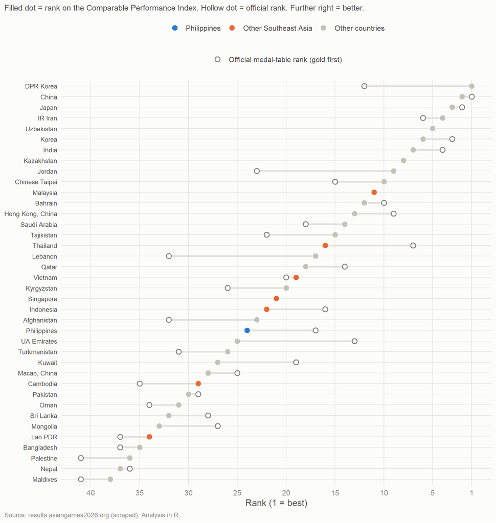

Figure 1: Official medal-table rank vs. comparable-performance rank

Table 2 gives the values behind the index for every eligible country. The Philippines is highlighted.

Table 2: Comparable measures for every country with at least 25 entries, ordered by the Comparable Performance Index

[output not shown]

<sup>a</sup> Rank on the official medal table, which orders countries by golds, then silvers, then bronzes.  
<sup>b</sup> One competitor (athlete, pair or team) in one event.  
<sup>c</sup> Share of entries that won a medal.  
<sup>d</sup> Average share of each event's field that the country's entries finished ahead of.  
<sup>e</sup> Share of entries that finished in the top eight.  
<sup>f</sup> Opponent-adjusted rating from every match, bout and game (0 = average).  
<sup>g</sup> Medal points won ÷ medal points expected from population, GDP per person, host status and team size. A dash means no GDP figure (DPR Korea).  
<sup>h</sup> Comparable Performance Index: average percentile (0–100) of the five measures to its left (rate measures adjusted for small teams).

## Is the ranking robust?

An index is only useful if its verdict does not depend on arbitrary choices. Figure 2 rebuilds it four ways: the baseline; allowing for population and wealth but not team size; with no resource adjustment at all; and with competitive quality alone (field beaten and head-to-head strength).

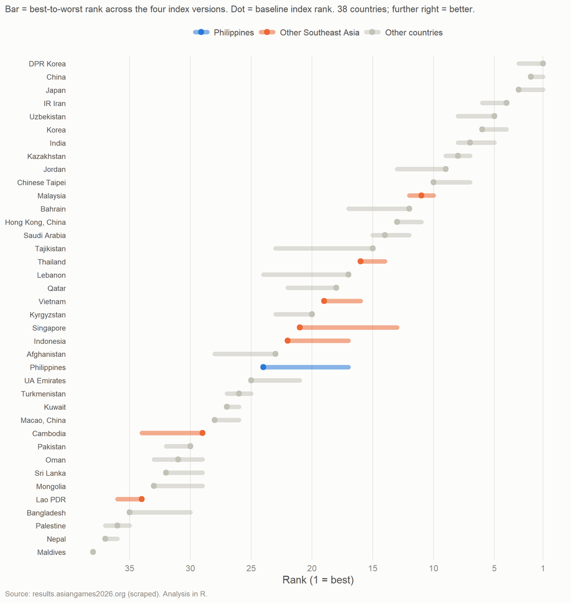

Figure 2: How much each country’s rank moves when the index is built differently

The Philippines moves between #17 (version: Competitive quality only (field beaten and head-to-head)) and #24 (version: Baseline (population, wealth and team size)). Its best case equals its official rank, so no version of the index lifts it above the medal table.

## Depth of results and conversion

Figure 3 separates *how far into the field* a country’s athletes went (horizontal) from *how often that became a medal* (vertical). Countries to the right but low down reach finals without winning medals.

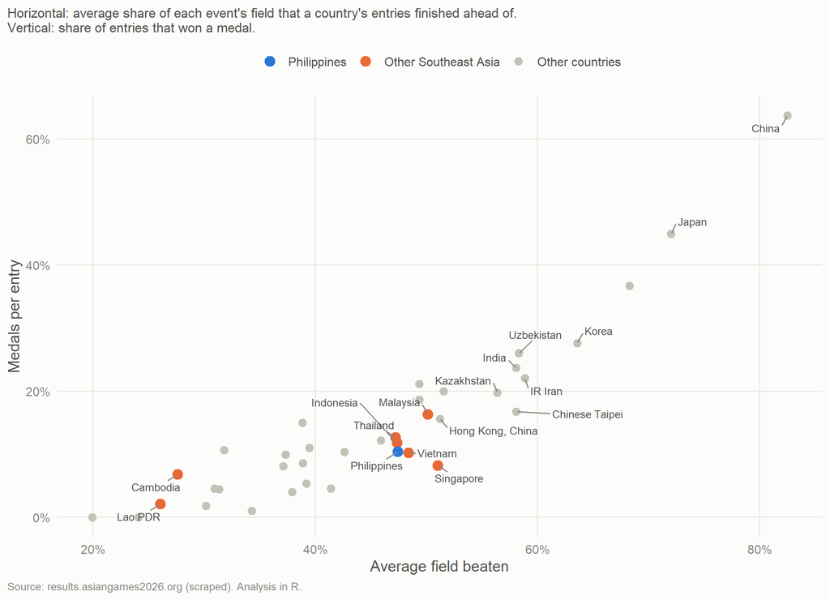

Figure 3: How deep into the field each country finished, and how often that became a medal

The Philippines beat 47.4% of the field on average, close to the middle of the pack, but converted only 10.4% of entries into medals.

## Medals against expectations

Figure 4 compares the medal points each country won with what a country of its population, GDP per person and host status would be expected to win. Points above the dashed line beat expectations.

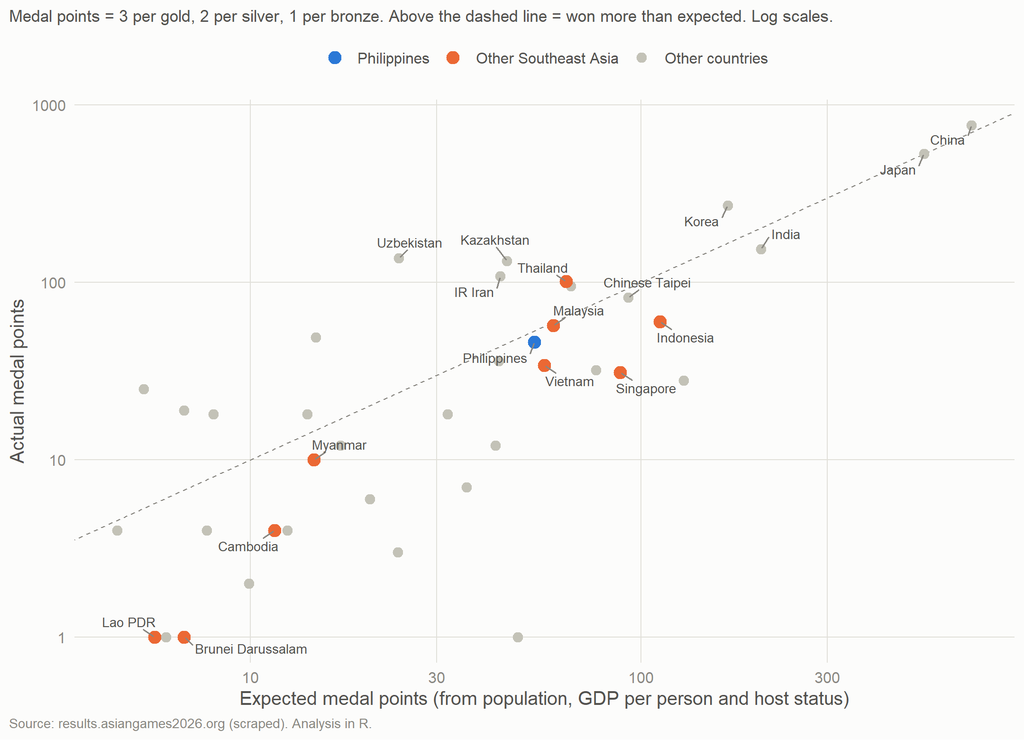

Figure 4: Medal points won vs. what population and wealth predict

The Philippines won 46 medal points against an expected 53 (ratio 0.86), slightly below the line. If the expectation also allows for its large team, the expected figure rises to 85 and the ratio falls to 0.54. The model coefficients are in the Excel download.

## Southeast Asia

Figure 5 compares the Philippines with its regional neighbours on four measures that do not depend on team size.

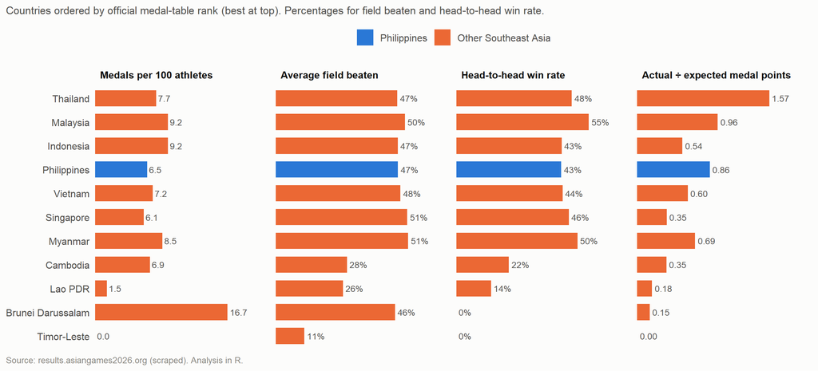

Figure 5: Southeast Asia: four ways to compare the region’s teams

Thailand leads the region relative to its resources. The Philippines is in the lower middle of the region on medals per 100 athletes, field beaten and head-to-head win rate, but third on actual ÷ expected medal points, ahead of Indonesia, Vietnam and Singapore.

## The Philippines in detail

### Results by sport

Figure 6 shows, for each sport the Philippines entered, how far into the field its athletes finished on average, with the medal, top-8 and entry counts beside each bar.

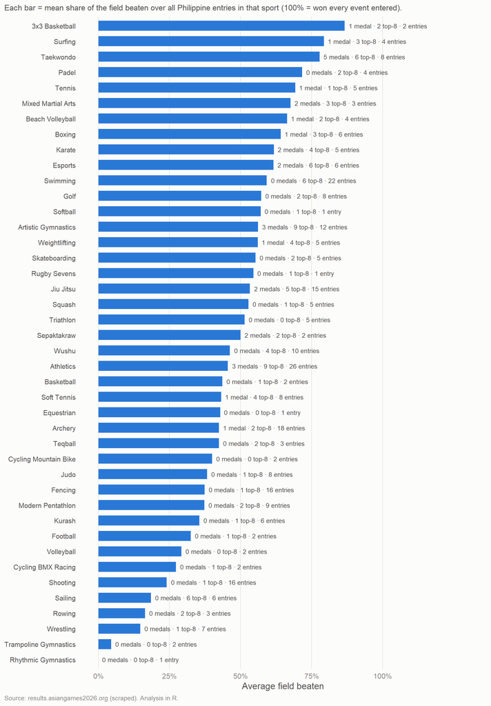

Figure 6: The Philippines by sport: how far into the field its entries finished

### Medals

Table 3 lists all 29 Philippine medals, golds first, then by date.

Table 3: Every Philippine medal at Aichi-Nagoya 2026

| Date | Medal | Sport | Event | Athlete or team | Field size<sup>a</sup> |
| --- | --- | --- | --- | --- | --- |
| 24 Sep | Gold | Artistic Gymnastics | Men's Floor Exercise | YULO Carlos Edriel | 8 |
| 25 Sep | Gold | Artistic Gymnastics | Men's Vault | YULO Carlos Edriel | 8 |
| 29 Sep | Gold | Athletics | Men's Pole Vault | OBIENA Ernest John | 12 |
| 02 Oct | Gold | Taekwondo | Mixed Individual Virtual Taekwondo | YAPE Jeus Gabriel Derick | 16 |
| 22 Sep | Silver | Mixed Martial Arts | Men's Traditional -65kg | SACLAG Jean Claude | 9 |
| 25 Sep | Silver | 3x3 Basketball | Women | KA Kennan; ESPANOL Amyah; PASILANG Maria; DELA ROSA Quinn | 16 |
| 29 Sep | Silver | Sepaktakraw | Women's Double | SALON Nelly Jay; SUCALIT Jean Marie; SINOGBUHAN Abegail | 4 |
| 01 Oct | Silver | Archery | Compound Women's Individual | COJUANGCO Amaya Amparo | 53 |
| 01 Oct | Silver | Taekwondo | Women Individual Poomsae | CANDELARIA Juliana Mykhail | 16 |
| 02 Oct | Silver | Boxing | Men's 55kg | PAALAM Carlo | 24 |
| 02 Oct | Silver | Taekwondo | Men -58kg | BARBOSA Kurt Bryan | 16 |
| 02 Oct | Silver | Taekwondo | Women -49kg | MANGIN Tachiana Keizha | 15 |
| 03 Oct | Silver | Jiu Jitsu | Women -63kg | ENRIQUEZ Alexandria Luz | 23 |
| 20 Sep | Bronze | Soft Tennis | Women's Team | CATINDIG Princess; MANALAC Noelle; SANOSA Christy; SALAZAR Shyryn; PAAS Hilary | 8 |
| 22 Sep | Bronze | Karate | Women's Team Kata | VEGUILLAS Samantha Emmanuelle; ARROGANTE Ysabielle; TORRES Rebecca Cyril | 8 |
| 22 Sep | Bronze | Mixed Martial Arts | Men's Traditional -77kg | ALVAREZ Carlos | 10 |
| 23 Sep | Bronze | Karate | Women's Kumite -50kg | ADRIANO Marie June | 13 |
| 25 Sep | Bronze | Artistic Gymnastics | Men's Horizontal Bar | YULO Karl Jahrel Eldrew | 8 |
| 26 Sep | Bronze | Weightlifting | Men's 70kg | DELOS SANTOS Albert Ian | 9 |
| 27 Sep | Bronze | Athletics | Men's 110m Hurdles | TOLENTINO John | 17 |
| 27 Sep | Bronze | Esports | MOBA [Pokémon UNITE] | DAVID Lance; LEONCIO Ducke Harnold; GATMAITAN Lawrence Anthony; SALAZAR Kim Rey; MEMPIN Robert Jon; OCIO Michael Vaughn | 10 |
| 28 Sep | Bronze | Esports | MOBA [Honor of Kings] | DAJAO Golden Hart; TAN Justine Ritchie; ESGUERRA Charles Roman; DAJAO Dragon Hart; TUNGOL Jhon Mike; NAZARREA Chammy Paul | 10 |
| 29 Sep | Bronze | Athletics | Women's 800m | BOSSONG Victoria | 14 |
| 29 Sep | Bronze | Sepaktakraw | Men's Regu | HUERTE Jason; RAFAEL Jom Lerry; ASILUM Reynaldo Jr.; PHORI Glindel; GABAYERON Ronsited | 4 |
| 29 Sep | Bronze | Surfing | Men's Shortboard | ALCISO Jayuard | 23 |
| 01 Oct | Bronze | Taekwondo | Men Individual Poomsae | YAPE Jeus Gabriel Derick | 15 |
| 02 Oct | Bronze | Beach Volleyball | Women's | PROGELLA Khylem Harl; PAGARA Sofiah Shanine | 26 |
| 02 Oct | Bronze | Jiu Jitsu | Women -52kg | NAPOLIS Jenna Kaila | 17 |
| 02 Oct | Bronze | Tennis | Women's Singles | EALA Alexandra | 30 |

<sup>a</sup> Number of entries that started the event.

### Near misses

A near miss is a 4th or 5th place without a medal. In sports that award two bronzes (combat sports, for example) 5th place means losing the bronze-medal bout. Table 4 lists all 44.

Table 4: Philippine 4th and 5th places (near misses)

| Place<sup>a</sup> | Sport | Event | Athlete or team | Field size<sup>b</sup> |
| --- | --- | --- | --- | --- |
| 4 | 3x3 Basketball | Men | PABLO Manuel; CABANERO Nicael; DUNGO David; BUENAFLOR Koji | 16 |
| 4 | Artistic Gymnastics | Men's Parallel Bars | YULO Carlos Edriel | 8 |
| 4 | Padel | Women's Pairs | ABAD Danna; MALAZARTE Joshea | 23 |
| 4 | Sailing | Boys' Windsurfing | CASTILLO Dhenver John | 6 |
| 4 | Skateboarding | Men's Park | FRANCISCO Jericho | 13 |
| 4 | Softball | Softball Women | ELLAZAR Skylynne Kopia; MAGBANUA Ma. Victoria; ALTOMONTE Francesca; CRUZ Roma Jane; TUBONGBANUA Mea; VILLAMIN Reyae Mae; HAMMOUDE Nicole Adra; PALMA Royevel; GABRIEL Ma. Angelu; LAURENTE Mary Joy; VIT… | 8 |
| 4 | Surfing | Men's Shortboard | ESPEJON Toby | 23 |
| 4 | Swimming | Women's 100m Freestyle | SANCHEZ Kayla | 35 |
| 4 | Swimming | Women's 50m Freestyle | SANCHEZ Kayla | 35 |
| 4 | Weightlifting | Women's 53kg | RAMOS Rosegie | 13 |
| 4 | Weightlifting | Women's 69kg | MACROHON Kristel | 10 |
| 5 | Artistic Gymnastics | Men's Vault | BESANA Juancho Miguel | 8 |
| 5 | Athletics | Men's 5000m | GUERMALI Yacine | 18 |
| 5 | Athletics | Women's 4 x 100m Relay | JOHNSON Naomi; LAURANCE Jessica Rose; PAMA Lianne Diana; NELSON Zion Rose | 11 |
| 5 | Basketball | Women | BERNARDINO Afril; PASTRANA Kent; PONTEJOS Janine; SURADA Angelica; YAM Hazelle; BERBERABE Stefani; DEL CARMEN Monique; JOSON Jhazmin; PINGOL Karl; CLARIN Camille; MEANS Elizabeth; MALAGAR Camille | 11 |
| 5 | Beach Volleyball | Women's | PONS Bernadeth; RONDINA Cherry Ann | 26 |
| 5 | Boxing | Men's 60kg | OGAYRE Junmilardo | 28 |
| 5 | Boxing | Women's 60kg | PETECIO Nesthy | 16 |
| 5 | Esports | 1v4 asymmetrical survival game [Identity V - Asian Games Version] | JUICO Johannes Glenn; GUMARO Joshua Francis; TIMTIMAN Joachim Santino; CORTEZ Psalm David; GALLO Sander Joseph Creed; JULIAN Xyrel Terrence; ONQUIT Japhet Jay | 10 |
| 5 | Esports | Action-adventure / Battle Royale [NARAKA : BLADEPOINT] | TENOSO Ouhric Von; ESPEJO Richard; PACLIBAR Raphaelron Joaquin; PEREZ Kenneth | 8 |
| 5 | Esports | MOBA [Mobile Legends: Bang Bang] | PABICO Alston; NEPOMUCENO Karl Gabriel; VIANA Dave Jr.; VINUYA Sanford; DELA CRUZ Jay Pee; PILLAS Grant Duane | 11 |
| 5 | Esports | Puzzle [Puyo Puyo Champions] | GONZALVO Karl Owen | 10 |
| 5 | Golf | Women's Individual Stroke Play | MALIXI Rianne Mikaela | 45 |
| 5 | Jiu Jitsu | Men -69kg | LIM Marc Alexander | 35 |
| 5 | Jiu Jitsu | Women -63kg | LAO Andrea Lois | 23 |
| 5 | Karate | Men's Kumite -75kg | BATICAN Alwyn | 10 |
| 5 | Kurash | Women -57kg | QUELINO Charmea | 21 |
| 5 | Modern Pentathlon | Men's Team | GERMAN Samuel; COMALING Michael Ver Anton; ANDRINO Gilbert | 5 |
| 5 | Padel | Men's Pairs | LAPIDUS Jason; CANIZARES Argil | 20 |
| 5 | Sailing | Women's Windsurfing | PAZ Arrianne | 7 |
| 5 | Skateboarding | Women's Park | PARIS Mazel | 14 |
| 5 | Soft Tennis | Men's Singles | NUGUIT Sherwin | 22 |
| 5 | Soft Tennis | Men's Team | TALATAYOD Dheo; NUGUIT Sherwin; NUGUIT Samuel; ALCOSEBA Mark; ARCILLA Joseph | 11 |
| 5 | Soft Tennis | Mixed Doubles | SANOSA Christy; NUGUIT Sherwin | 19 |
| 5 | Squash | Mixed Doubles | PELINO David; ARIBADO Jemyca | 20 |
| 5 | Surfing | Women's Shortboard | ESPANOLA Juralyn | 21 |
| 5 | Swimming | Women's 50m Backstroke | SANCHEZ Kayla | 31 |
| 5 | Taekwondo | Women -57kg | CANABAL Baby Jessica | 15 |
| 5 | Teqball | Men's Singles | AGUSTIN Prince | 11 |
| 5 | Weightlifting | Women's 61kg | ANDO Elreen Ann | 12 |
| 5 | Wrestling | Men's Greco-Roman 87kg | ROBERTS Callum Johnston | 12 |
| 5 | Wushu | Men's 60kg | PADUA Gideon Fred | 11 |
| 5 | Wushu | Men's 65kg | ALIPIO Xander | 17 |
| 5 | Wushu | Men's Daoshu & Gunshu | RAGAY Mark Lester | 10 |

<sup>a</sup> Final classification. Tied places share the same number.  
<sup>b</sup> Number of entries that started the event.

### Head-to-head record

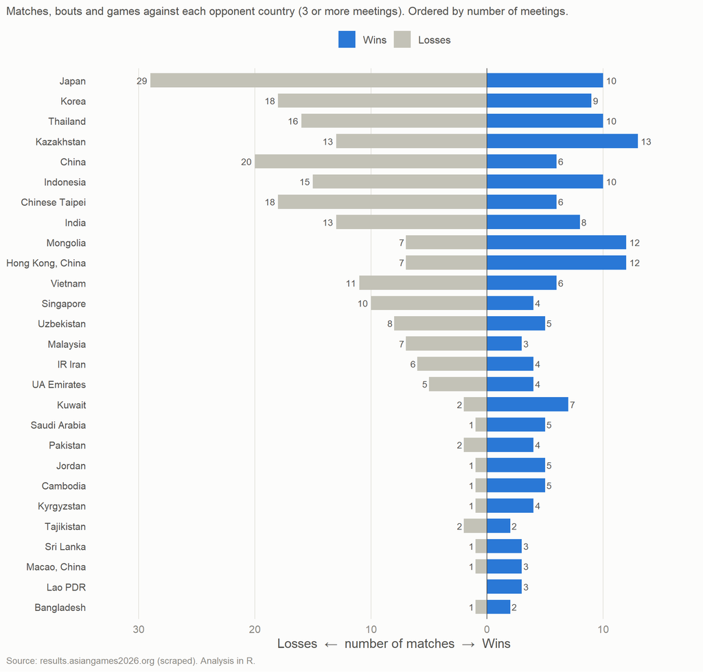

Figure 7: The Philippines’ head-to-head record, by opponent

Because a raw win rate depends on who you happened to play, Figure 8 adjusts for opponent strength. The Philippines ranks #18 of 38 on this rating.

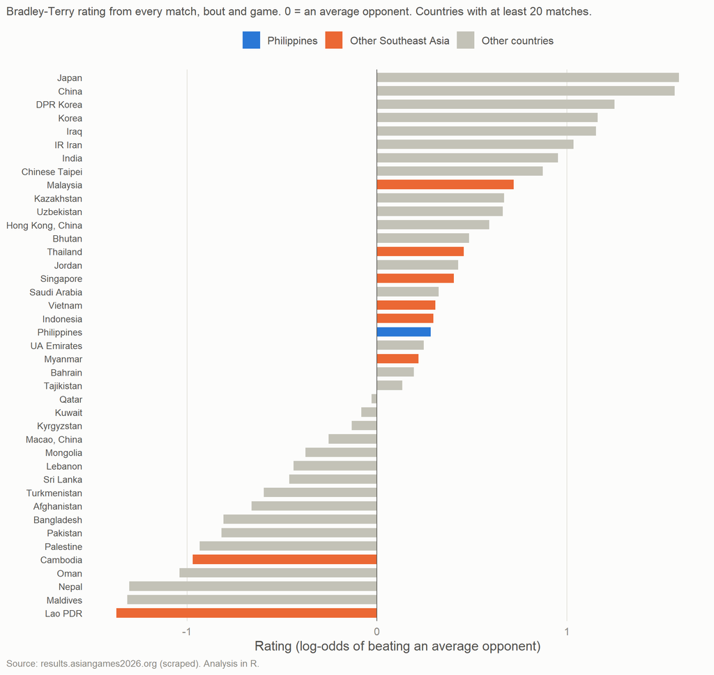

Figure 8: Head-to-head strength, adjusted for the opponents each country faced

## Caveats

**WarningLimits of this analysis**

- **Head-to-head counts every match equally**, from group-stage games to finals. The individual rubbers inside a team tie are not counted separately.
- **Field beaten uses each sport’s official final classification.** Some sports rank every competitor individually; others give every quarter-final loser 5th place. Both are used as published.
- **Population and GDP adjustments.** DPR Korea has no World Bank GDP figure, so it has no actual ÷ expected value. Chinese Taipei’s population and GDP come from Taiwan’s official statistics.
- **Missing units.** 3 provisional units (one equestrian dressage test, one surfing heat, one sailing race) had no published results when the data was scraped. They do not affect any medal.
- Results are as published on results.asiangames2026.org at the time of scraping.